# Visualização dos Dados de Honorários Públicos do Portal da Transparência com R

Felipe Guerra de Figueiredo

2026-02-27

## Introdução

Este tutorial apresenta um passo a passo para **visualizar os valores de honorários advocatícios pagos no âmbito do Poder Executivo Federal**, a partir de microdados extraídos do Portal da Transparência (CGU) utilizando o software/linguagem R.

O objetivo é:

- Consolidar arquivos mensais de honorários
- Tratar inconsistências e identificadores ausentes
- Transformar os microdados em séries de tempo (valor total, número de servidores e honorário médio por servidor)
- Visualizar a evolução temporal da despesa

O código foi estruturado para ser **reprodutível**, **auditável** e adaptável para outros recortes institucionais.

## Pacotes utilizados

Começamos carregando os pacotes necessários para manipulação de dados, visualização e apresentação de tabelas.

```r
# Manipulação de dados
library(tidyverse)
library(readr)
library(dplyr)

# Gráficos e tabelas
library(ggplot2)
library(ggrepel)
library(scales)
library(knitr)
library(kableExtra)
```

## Leitura e consolidação dos arquivos de honorários

Os dados de honorários advocatícios constam no Portal da Transparência da Controladoria-Geral da União (CGU) e estão disponíveis no endereço: https://portaldatransparencia.gov.br/download-de-dados/servidores

Para reproduzir os resultados, selecione o Exercício Disponível (no caso dos honorários, de 2018 a 2026), o mês de interesse e o tipo de planilha (Honorarios_Advocaticios), faça o download de cada mês individualmente e coloque todas em uma mesma pasta. Coloque no código o diretório da pasta onde estão os dados, caso contrário o código retornará uma mensagem de erro solicitando esse passo.

É conveniente definir um filtro por nome de arquivo, usando uma expressão regular como `HonorariosAdvocaticios` ou outra expressão de preferência, além de definir a extensão do arquivo com `\\.csv` e a terminação `$`, que garante que o nome do arquivo termina exatamente em .csv. Com isso, apenas os arquivos corretos são selecionados, mesmo que existam outros CSVs na mesma pasta.

```r
# Defina a variável pasta_honorarios com o diretório onde estão os arquivos de honorários
# Exemplo:
# pasta_honorarios <- "C:/MeusDocumentos/Honorarios"

pasta_honorarios <- Sys.getenv("DIRETORIO_HONORARIOS") # Coloque aqui seu diretório

if (pasta_honorarios == "") {
  stop("Defina o caminho da pasta onde estão os dados.")
}

arquivos_honorarios <- list.files(
  path = pasta_honorarios,
  pattern = "HonorariosAdvocaticios\\.csv$",
  full.names = TRUE
)
```

### Função de leitura padronizada

Para garantir consistência no tratamento dos dados, definimos uma função que:

- Lê os arquivos com separador `;`
- Converte corretamente valores monetários
- Ajusta os tipos das variáveis temporais

A função `ler_honorarios()` foi criada para padronizar a leitura e o tratamento inicial dos arquivos mensais de honorários advocatícios extraídos do Portal da Transparência.

Ela garante que todos os arquivos: i) sejam lidos corretamente no padrão brasileiro; ii) tenham tipos de variáveis consistentes; iii) estejam prontos para consolidação em uma única base.

A função recebe como argumento o caminho de um arquivo CSV (arquivo) e devolve um data frame já tratado.

```r
# Função de leitura dos dados

ler_honorarios <- function(arquivo) {
  df <- read_delim(
    arquivo,
    delim = ";",
    locale = locale(decimal_mark = ","),
    show_col_types = FALSE,
    col_types = cols(.default = col_character())
  )

  df %>%
    mutate(
      across(
        matches("VALOR|HONOR", ignore.case = TRUE),
        ~ as.numeric(str_replace_all(.x, ",", "."))
      ),
      MES = as.integer(MES),
      ANO = as.integer(ANO)
    )
}
```

A função `read_delim()` lê arquivos separados por delimitadores personalizados (no caso, ;). O argumento `arquivo` permite aplicar a função a qualquer arquivo da pasta, mês a mês.

Na segunda metade do bloco acima são definidas os tipos de variáveis. Em particular, para valores monetários são selecionadas automaticamente todas as colunas cujo nome contenha `VALOR` ou `HONOR`, substitui a vírgula decimal por ponto (padrão do R) e converte para formato numérico.

### Consolidação da base

Com a função definida, lemos os arquivos e empilhamos todos em um único *data frame*.

```r
# Consolidando

honorarios <- arquivos_honorarios %>%
  map_dfr(ler_honorarios)
```

## Seleção de variáveis e tratamento inicial

Mantemos apenas as variáveis essenciais para a análise e criamos um identificador temporal no formato `ano_mes`.

```r
# Criando ano_mes

honorarios <- honorarios %>%
  select(
    ANO, MES, Id_SERVIDOR_PORTAL, VALOR
  ) %>%
  mutate(
    ano_mes = sprintf("%d%02d", ANO, MES)
  )
```

### Observações sem identificador

Alguns registros não possuem identificação de servidor. Avaliamos a magnitude desses valores antes de excluí-los da análise principal. Primeiro, uma contagem do número de observações sem ID e , em seguida, a soma do valor em R$ do total sem identificação ao longo de toda série.

```r
# Número de registros sem ID
sum(is.na(honorarios$Id_SERVIDOR_PORTAL))
```

```
## [1] 1607
```

```r
# Valor total não identificado
honorarios %>%
  filter(is.na(Id_SERVIDOR_PORTAL)) %>%
  summarise(total_na = sum(VALOR, na.rm = TRUE))
```

```
## # A tibble: 1 × 1
##   total_na
##      <dbl>
## 1 4388517.
```

```r
# Excluindo
honorarios <- honorarios %>%
  filter(!is.na(Id_SERVIDOR_PORTAL))

# Separando NAs
honorarios_sem_id <- honorarios %>%
  filter(is.na(Id_SERVIDOR_PORTAL))
```

## Consolidação mensal por servidor

Um mesmo servidor pode aparecer mais de uma vez no mesmo ano-mês, com diferentes valores a receber. Para evitar dupla contagem, agregamos esses valores mensalmente a nível individual.

```r
# Consolidação mensal

honorarios_mensal <- honorarios %>%
  group_by(
    Id_SERVIDOR_PORTAL,
    ANO,
    MES,
    ano_mes
  ) %>%
  summarise(
    VALOR_HONORARIOS = sum(VALOR, na.rm = TRUE),
    .groups = "drop"
  )
```

A seguir, podemos verificar a unicidade de id/ano_mes com um filtro simples. Para cada combinação de ID e ano-mês, vamos filtrar as observações maiores que 1. Portanto, se o filtro gerar um tibble sem linhas, temos apenas 1 de cada.

```r
honorarios_mensal %>%
  count(Id_SERVIDOR_PORTAL, ano_mes) %>%
  filter(n > 1)
```

```
## # A tibble: 0 × 3
## # ℹ 3 variables: Id_SERVIDOR_PORTAL <chr>, ano_mes <chr>, n <int>
```

## Agregações mensais

Agora vamos transformar o microdado original em séries de tempo, criando as variáveis de:

- Valor total pago em honorários
- Número de servidores beneficiados
- Valor médio por servidor

Adicionalmente, também vamos criar uma variável de data, para maior conveniência no trabalho com séries de tempo.

```r
honorarios_evolucao <- honorarios_mensal %>%
  group_by(ano_mes) %>%
  summarise(
    total_honorarios = sum(VALOR_HONORARIOS, na.rm = TRUE),
    servidores = n_distinct(Id_SERVIDOR_PORTAL),
    media_por_servidor = total_honorarios / servidores,
    .groups = "drop"
  ) %>%
  mutate(
    ano_mes_date = as.Date(paste0(ano_mes, "01"), format = "%Y%m%d")
  )
```

## Evolução do valor total de honorários

### Indicadores simples

O bloco a seguir calcula crescimento mensal da série computando a variação percentual mensal. Depois computa-se a média dessa variação percentual e o total de honorários pagos durante todo o período da série. Essas informações erão incluídas no gráfico seguinte.

```r
dados_crescimento <- honorarios_evolucao %>%
  arrange(ano_mes_date) %>%
  mutate(
    crescimento_mensal = total_honorarios / lag(total_honorarios) - 1
  ) %>%
  filter(!is.na(crescimento_mensal))

g_mensal <- mean(dados_crescimento$crescimento_mensal, na.rm = TRUE)
total_periodo <- sum(honorarios_evolucao$total_honorarios, na.rm = TRUE)
```

### Série completa

O bloco a seguir traz o gráfico do total mensal pago em honorários advocatícios, incluindo as informações calculadas anteriormente no canto superior esquerdo da imagem.

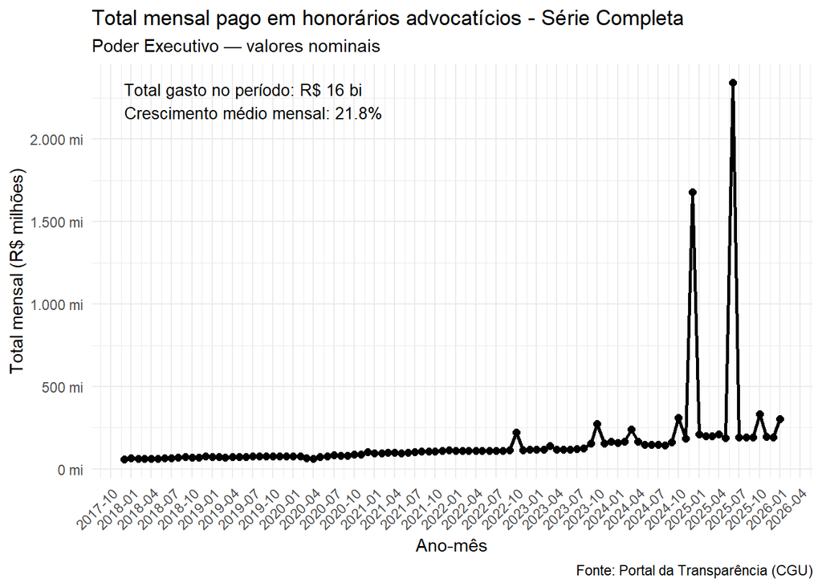

```r
texto_anotacao <- paste0(
  "Total gasto no período: R$ ",
  label_number(big.mark = ".", decimal.mark = ",", scale = 1e-9, suffix = " bi")(total_periodo),
  "\nCrescimento médio mensal: ",
  percent(g_mensal, accuracy = 0.1)
)

ggplot(honorarios_evolucao,
       aes(x = ano_mes_date, y = total_honorarios)) +
  geom_line(linewidth = 1) +
  geom_point(size = 2) +
  scale_y_continuous(
    labels = label_number(
      big.mark = ".", decimal.mark = ",", scale = 1e-6, suffix = " mi"
    )
  ) +
  scale_x_date(date_breaks = "3 months", date_labels = "%Y-%m") +
  labs(
    title = "Total mensal pago em honorários advocatícios - Série Completa",
    subtitle = "Poder Executivo — valores nominais",
    x = "Ano-mês",
    y = "Total mensal (R$ milhões)",
    caption = "Fonte: Portal da Transparência (CGU)"
  ) +
  annotate(
    "text",
    x = min(honorarios_evolucao$ano_mes_date),
    y = max(honorarios_evolucao$total_honorarios),
    label = texto_anotacao,
    hjust = 0,
    vjust = 1,
    size = 3.5
  ) +
  theme_minimal() +
  theme(axis.text.x = element_text(angle = 45, hjust = 1))
```

Note que os picos nos meses de dez/2024 e jun/2025 atrapalham muito a visualização do gráfico pois altera a escala do eixo vertical. Para contornar isso, podemos plotar a série apenas até o período de nov/2024 para avaliar melhor a parte inicial dos dados.

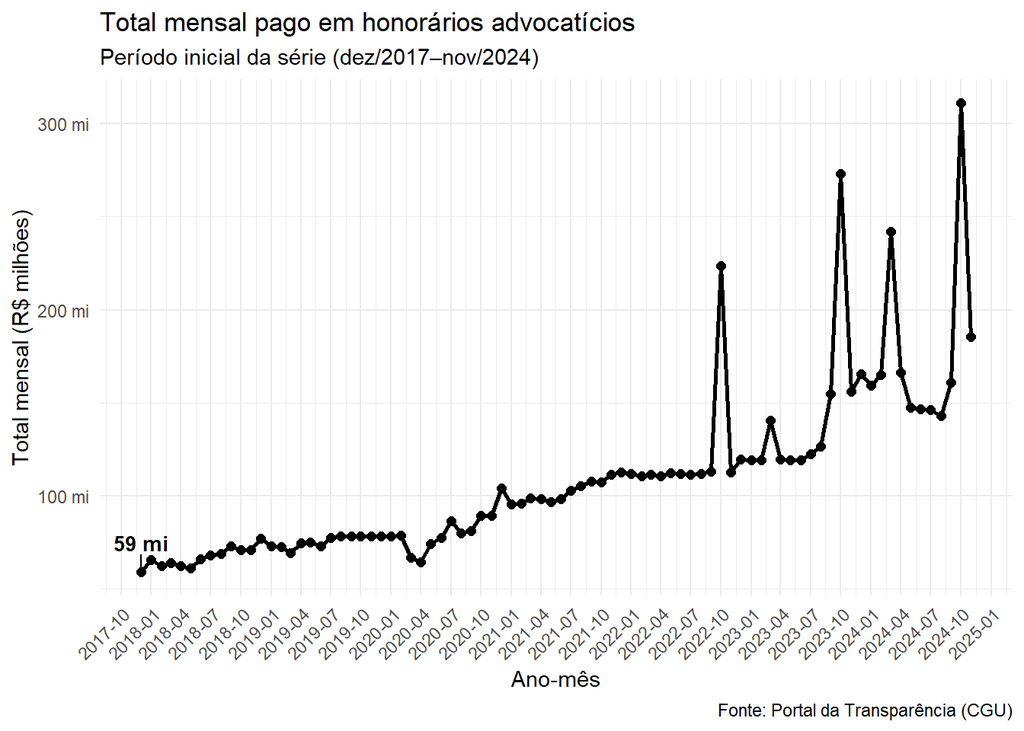

```r
# Gráfico 2 — Total mensal (dez/2017 a nov/2024), antes dos grandes picos

# Separando período inicial
honorarios_total_pre_pico <- honorarios_evolucao %>%
  filter(ano_mes_date <= as.Date("2024-11-01"))

# Definindo rótulo inicial
rotulo_inicial <- honorarios_total_pre_pico %>%
  arrange(ano_mes_date) %>%
  slice(1) %>%
  mutate(
    label = scales::label_number(
      big.mark = ".", decimal.mark = ",",
      scale = 1e-6, suffix = " mi"
    )(total_honorarios)
  )

ggplot(honorarios_total_pre_pico,
       aes(x = ano_mes_date, y = total_honorarios)) +
  geom_line(linewidth = 1) +
  geom_point(size = 2) +

  # Rótulo apenas no primeiro mês
  geom_text_repel(
    data = rotulo_inicial,
    aes(label = label),
    size = 3.5,
    fontface = "bold",
    nudge_y = max(honorarios_total_pre_pico$total_honorarios) * 0.05,
    direction = "y",
    segment.size = 0.4
  ) +

  scale_y_continuous(
    labels = scales::label_number(
      big.mark = ".", decimal.mark = ",",
      scale = 1e-6, suffix = " mi"
    )
  ) +
  scale_x_date(
    date_breaks = "3 months",
    date_labels = "%Y-%m"
  ) +
  labs(
    title = "Total mensal pago em honorários advocatícios",
    subtitle = "Período inicial da série (dez/2017–nov/2024)",
    x = "Ano-mês",
    y = "Total mensal (R$ milhões)",
    caption = "Fonte: Portal da Transparência (CGU)"
  ) +
  theme_minimal() +
  theme(
    axis.text.x = element_text(angle = 45, hjust = 1)
  )
```

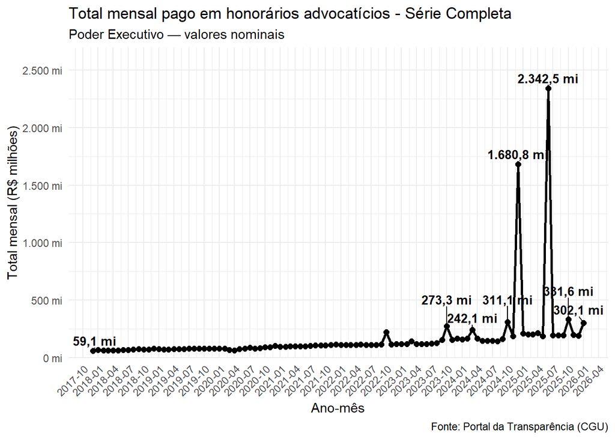

```r
# Gráfico 3 - Incluir rótulo de dados nos 5 maiores valores e no menor

# Identificando pontos
rotulos_extremos <- honorarios_evolucao %>%
  arrange(desc(total_honorarios)) %>%
  slice_head(n = 7) %>%
  bind_rows(
    honorarios_evolucao %>%
      arrange(total_honorarios) %>%
      slice_head(n = 1)
  ) %>%
  distinct(ano_mes_date, .keep_all = TRUE)

# Alterando o limite do eixo y
 limite_y <- max(honorarios_evolucao$total_honorarios, na.rm = TRUE) * 1.15

# Gráfico
ggplot(honorarios_evolucao,
       aes(x = ano_mes_date, y = total_honorarios)) +
  geom_line(linewidth = 1) +
  geom_point(size = 2) +

  # Rótulos apenas nos extremos
  geom_text_repel(
    data = rotulos_extremos,
    aes(label = scales::label_number(
      big.mark = ".", decimal.mark = ",",
      scale = 1e-6, suffix = " mi"
    )(total_honorarios)),
    size = 3.5,
    fontface = "bold",
    segment.size = 0.4,
    min.segment.length = 0,
    nudge_y = limite_y * 0.02,
    direction = "y"
  ) +

  scale_y_continuous(
    limits = c(0, limite_y),
    breaks = scales::pretty_breaks(n = 7),
    labels = scales::label_number(
      big.mark = ".", decimal.mark = ",",
      scale = 1e-6, suffix = " mi"
    ),
    expand = expansion(mult = c(0, 0))
  ) +
  scale_x_date(
    date_breaks = "3 months",
    date_labels = "%Y-%m"
  ) +
  labs(
    title = "Total mensal pago em honorários advocatícios - Série Completa",
    subtitle = "Poder Executivo — valores nominais",
    x = "Ano-mês",
    y = "Total mensal (R$ milhões)",
    caption = "Fonte: Portal da Transparência (CGU)"
  ) +
  theme_minimal() +
  theme(
    axis.text.x = element_text(angle = 45, hjust = 1)
  )
```

Mas se estamos interessados na evolução anual dos valores, um gráfico de barras anual pode ser mais informativo para visualizar a tendência da série.

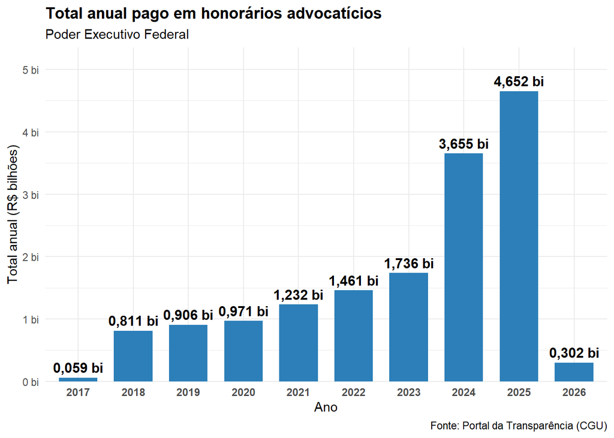

```r
# GRáfico de barras ano a ano
# Agregação anual dos honorários
honorarios_anual <- honorarios_evolucao %>%
  mutate(ANO = as.integer(substr(ano_mes, 1, 4))) %>%
  group_by(ANO) %>%
  summarise(
    total_honorarios = sum(total_honorarios, na.rm = TRUE),
    .groups = "drop"
  )

ggplot(honorarios_anual,
       aes(x = factor(ANO), y = total_honorarios)) +
  geom_col(fill = "#2C7FB8", width = 0.7) +

  # Rótulos de valor
  geom_text(
    aes(label = scales::label_number(
      big.mark = ".", decimal.mark = ",",
      scale = 1e-9, suffix = " bi"
    )(total_honorarios)),
    vjust = -0.5,
    size = 4,
    fontface = "bold"
  ) +

  scale_y_continuous(
    labels = scales::label_number(
      big.mark = ".", decimal.mark = ",",
      scale = 1e-9, suffix = " bi"
    ),
    expand = expansion(mult = c(0, 0.15))
  ) +

  labs(
    title = "Total anual pago em honorários advocatícios",
    subtitle = "Poder Executivo Federal",
    x = "Ano",
    y = "Total anual (R$ bilhões)",
    caption = "Fonte: Portal da Transparência (CGU)"
  ) +

  theme_minimal() +
  theme(
    axis.text.x = element_text(face = "bold"),
    plot.title = element_text(face = "bold")
  )
```

## Evolução do valor médio por servidor

Por fim, analisamos a trajetória do valor médio mensal de honorários pagos por servidor. Note que, como o número de servidores permanece relativamente estável no período, o padrão da série é semelhante ao padrão da série de valor total mensal, também com picos em jun/2025 e dez/2024 que atrapalham a visualização da série. Por isso, vamos colocar rótulo de dados em algumas observações ao longo de toda série para melhorar a visualização.

Queremos rotular apenas os **picos locais**. Assim, para cada mês, o código verifica se o valor médio é maior que o mês anterior **e** maior que o mês seguinte. Se sim, então é um pico local.

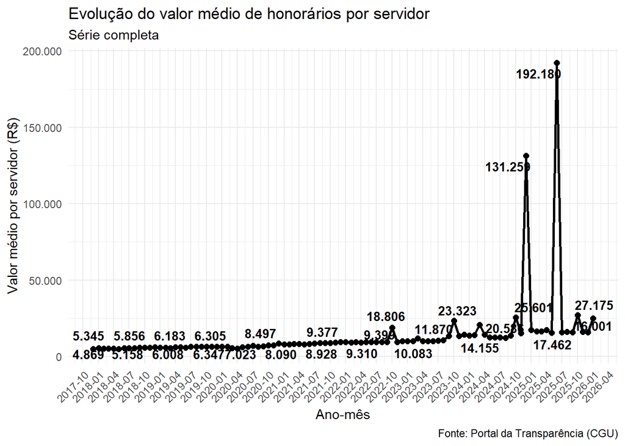

```r
honorarios_rotulos <- honorarios_evolucao %>%
  arrange(ano_mes_date) %>%
  mutate(
    pico = media_por_servidor > lag(media_por_servidor) &
      media_por_servidor > lead(media_por_servidor)
  ) %>%
  filter(pico | row_number() == 1)

ggplot(honorarios_evolucao, aes(x = ano_mes_date, y = media_por_servidor)) +
  geom_line(linewidth = 1) +
  geom_point(size = 2) +
  geom_text_repel(
    data = honorarios_rotulos,
    aes(label = label_number(big.mark = ".", decimal.mark = ",")(media_por_servidor)),
    size = 3.5,
    fontface = "bold",
    segment.size = 0.4
  ) +
  scale_y_continuous(labels = label_number(big.mark = ".", decimal.mark = ",")) +
  scale_x_date(date_breaks = "3 months", date_labels = "%Y-%m") +
  labs(
    title = "Evolução do valor médio de honorários por servidor",
    subtitle = "Série completa",
    x = "Ano-mês",
    y = "Valor médio por servidor (R$)",
    caption = "Fonte: Portal da Transparência (CGU)"
  ) +
  theme_minimal() +
  theme(axis.text.x = element_text(angle = 45, hjust = 1))
```

## Tabela: Top 10 Maiores Valores

Podemos também fazer uma tabela para visualizar os dados disponíveis nos 10 meses em que foram distribuídos mais honorários aos servidores.

```r
# Criando tabela
top_10_meses <- honorarios_evolucao %>%
  arrange(desc(total_honorarios)) %>%
  slice_head(n = 10) %>%
  mutate(
    `Ano-mês` = format(ano_mes_date, "%Y-%m"),
    `Total mensal (R$ milhões)` = scales::number(
      total_honorarios / 1e6,
      big.mark = ".",
      decimal.mark = ",",
      accuracy = 0.01
    ),
    `Média por servidor (R$)` = scales::number(
      media_por_servidor,
      big.mark = ".",
      decimal.mark = ",",
      accuracy = 0.01
    ),
    Servidores = scales::number(
      servidores,
      big.mark = ".",
      decimal.mark = ",",
      accuracy = 1
    )
  ) %>%
  select(
    `Ano-mês`,
    `Total mensal (R$ milhões)`,
    Servidores,
    `Média por servidor (R$)`
  )


# Formatação da tabela
kable(
  top_10_meses,
  format = "html",
  caption = "Top 10 meses com maior gasto em honorários advocatícios – Poder Executivo",
  align = c("c", "r", "r", "r"),
  escape = FALSE
) %>%
  kable_styling(
    bootstrap_options = c("striped", "hover", "condensed"),
    full_width = FALSE,
    position = "center"
  ) %>%
  column_spec(2, bold = TRUE) %>%
  row_spec(0, bold = TRUE) %>%
  footnote(
    general = "Fonte: Portal da Transparência (CGU)",
    general_title = "",
    footnote_as_chunk = TRUE,
    escape = FALSE
  )
```

Top 10 meses com maior gasto em honorários advocatícios – Poder Executivo

| Ano-mês | Total mensal (R$ milhões) | Servidores | Média por servidor (R$) |
| --- | --- | --- | --- |
| 2025-06 | 2.342,48 | 12.189 | 192.180,03 |
| 2024-12 | 1.680,77 | 12.805 | 131.258,51 |
| 2025-10 | 331,59 | 12.202 | 27.175,45 |
| 2024-10 | 311,12 | 12.153 | 25.600,52 |
| 2026-01 | 302,08 | 12.162 | 24.837,81 |
| 2023-10 | 273,32 | 11.719 | 23.322,65 |
| 2024-03 | 242,11 | 11.761 | 20.585,78 |
| 2022-10 | 223,58 | 11.889 | 18.805,89 |
| 2025-04 | 212,79 | 12.186 | 17.461,69 |
| 2025-01 | 209,34 | 12.141 | 17.242,10 |

Fonte: Portal da Transparência (CGU)

Por fim, podemos incluir ainda a tabela com a série completa de microdados agregados em ordem cronológica.

```r
# Tabela Completa - Dados mensais

# Criando tabela – Série completa (todos os meses)
tabela_meses_completa <- honorarios_evolucao %>%
  arrange(ano_mes_date) %>%
  mutate(
    `Ano-mês` = format(ano_mes_date, "%Y-%m"),
    `Total mensal (R$ milhões)` = scales::number(
      total_honorarios / 1e6,
      big.mark = ".",
      decimal.mark = ",",
      accuracy = 0.01
    ),
    `Média por servidor (R$)` = scales::number(
      media_por_servidor,
      big.mark = ".",
      decimal.mark = ",",
      accuracy = 0.01
    ),
    Servidores = scales::number(
      servidores,
      big.mark = ".",
      decimal.mark = ",",
      accuracy = 1
    )
  ) %>%
  select(
    `Ano-mês`,
    `Total mensal (R$ milhões)`,
    Servidores,
    `Média por servidor (R$)`
  )

# Formatação
kable(
  tabela_meses_completa,
  format = "html",
  caption = "Gasto mensal com honorários advocatícios – Poder Executivo (série completa)",
  align = c("c", "r", "r", "r"),
  escape = FALSE
) %>%
  kable_styling(
    bootstrap_options = c("striped", "hover", "condensed"),
    full_width = FALSE,
    position = "center"
  ) %>%
  column_spec(2, bold = TRUE) %>%
  row_spec(0, bold = TRUE) %>%
  footnote(
    general = "Fonte: Portal da Transparência (CGU)",
    general_title = "",
    footnote_as_chunk = TRUE,
    escape = FALSE
  )
```

Gasto mensal com honorários advocatícios – Poder Executivo (série completa)

| Ano-mês | Total mensal (R$ milhões) | Servidores | Média por servidor (R$) |
| --- | --- | --- | --- |
| 2017-12 | 59,11 | 12.138 | 4.869,45 |
| 2018-01 | 65,60 | 12.273 | 5.345,09 |
| 2018-02 | 62,44 | 12.429 | 5.023,66 |
| 2018-03 | 64,19 | 12.445 | 5.157,89 |
| 2018-04 | 62,45 | 12.447 | 5.017,45 |
| 2018-05 | 61,31 | 12.438 | 4.929,22 |
| 2018-06 | 66,24 | 12.431 | 5.328,93 |
| 2018-07 | 68,09 | 12.442 | 5.472,20 |
| 2018-08 | 68,73 | 12.454 | 5.519,04 |
| 2018-09 | 72,84 | 12.439 | 5.855,82 |
| 2018-10 | 71,00 | 12.453 | 5.701,33 |
| 2018-11 | 71,00 | 12.452 | 5.701,64 |
| 2018-12 | 76,92 | 12.440 | 6.183,20 |
| 2019-01 | 72,95 | 12.494 | 5.838,84 |
| 2019-02 | 72,40 | 12.501 | 5.791,69 |
| 2019-03 | 69,44 | 12.440 | 5.581,62 |
| 2019-04 | 74,58 | 12.475 | 5.978,35 |
| 2019-05 | 74,91 | 12.468 | 6.008,11 |
| 2019-06 | 72,99 | 12.457 | 5.859,22 |
| 2019-07 | 77,64 | 12.440 | 6.241,20 |
| 2019-08 | 78,39 | 12.433 | 6.304,64 |
| 2019-09 | 78,23 | 12.438 | 6.289,48 |
| 2019-10 | 78,18 | 12.427 | 6.290,95 |
| 2019-11 | 78,25 | 12.423 | 6.298,49 |
| 2019-12 | 78,49 | 12.414 | 6.322,59 |
| 2020-01 | 78,49 | 12.411 | 6.324,60 |
| 2020-02 | 78,67 | 12.395 | 6.346,85 |
| 2020-03 | 66,96 | 12.387 | 5.405,93 |
| 2020-04 | 64,26 | 12.369 | 5.195,14 |
| 2020-05 | 74,38 | 12.341 | 6.026,99 |

[output cut: 68 more lines]

Fonte: Portal da Transparência (CGU)